# (Vector and) Raster Data in R

Advanced Geospatial Data Processing for Social Scientists

Dennis Abel & Stefan Jünger

2026-06-09

## Now

| Day | Time | Title |
| --- | --- | --- |
| June 9 | 10:00–11:15 | Introduction |
| June 9 | 11:15–11:30 | Coffee Break |
| June 9 | 11:30–13:00 | Raster data in R |
| June 9 | 13:00–14:00 | Lunch Break |
| June 9 | 14:00–15:15 | Raster data processing |
| June 9 | 15:15–15:30 | Coffee Break |
| June 9 | 15:30–17:00 | Graphical display of raster data in maps |
| June 10 | 10:00–11:15 | Datacube processing I |
| June 10 | 11:15–11:30 | Coffee Break |
| June 10 | 11:30–13:00 | Datacube processing II & API access |
| June 10 | 13:00–14:00 | Lunch Break |
| June 10 | 14:00–15:15 | Data integration and linking (with survey data) |
| June 10 | 15:15–15:30 | Coffee Break |
| June 10 | 15:30–17:00 | Outlook and open session with own application |

## Refresher: geospatial data and their implementation in `R`

## Why care about data types and formats?

There are differences in how spatial information is stored, processed, and visually represented.

- Different commands for data import and manipulation
- Spatial linking techniques and analyses partly determined by data format
- Visualization of data can vary

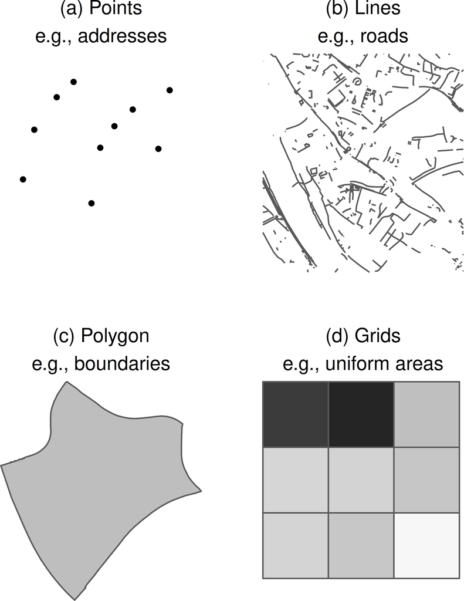

Source: OpenStreetMap / GEOFABRIK (2018), City of Cologne (2014), Statistical Offices of the Federation and the Länder (2016) / Jünger, 2019

## Vector data

## Representing the world in vectors

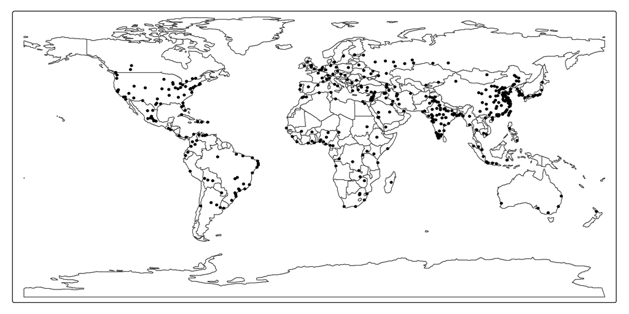

The surface of the earth is represented by simple geometries and attributes.

Each object is defined by longitude (x) and latitude (y) values.

It could also include z coordinates…

## Vector data: geometries

Every real-world feature is one of three types of geometry:

- Points: discrete location (e.g., a tree)
- Lines: linear feature (e.g., a river)
- Polygons: enclosed areas (e.g., a city, country, administrative boundaries)

[figure not shown]

Source: National Ecological Observatory Network (NEON), cited by [Datacarpentry](https://datacarpentry.org/organization-geospatial/instructor/02-intro-vector-data.html)

## Vector data: attribute tables

Only geometries means that we do not have any other information.

We must assign attributes to each geometry to hold additional information $\rightarrow$ data tables called attribute tables.

- Each row represents a geometric object, which we can also call observation, feature, or case
- Each column holds an attribute or, in ‘our’ language, a variable

## Vector data: attribute tables

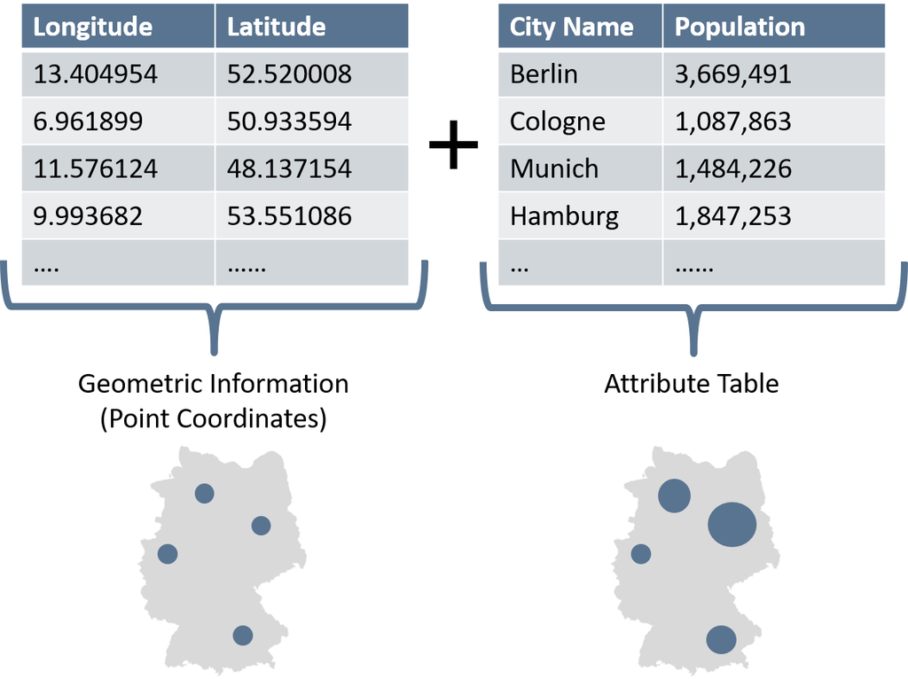

## File formats/extensions

- GeoPackage `.gpkg`
- Shapefile `.shp`
- GeoJSON `.geojson`
- …
- Sometimes, vector data come even in a text format, such as `CSV`

## Welcome to `simple features`

Several packages are out there to wrangle and visualize spatial and, especially, vector data within `R`. We often use the `sf` package (“simple features”). But there is also an implementation in the `terra` package we use for our raster data.

But why stick to `sf`?

`simple features` refers to a formal standard representing spatial geometries and supports interfaces to other programming languages and GIS systems (ISO 19125-1).

[figure not shown]

Source: Illustration by [Allison Horst](https://allisonhorst.com/r-packages-functions)

## Load a vector data file

The first step is, of course, loading the data. We want to import the `.geojson` file for the administrative borders of the whole world called `World_Countries.geojson`.

```r
# load library
library(sf)

# load data
# source: https://hub.arcgis.com/datasets/esri::world-countries-generalized/
hello_world <- sf::read_sf("./data/boundaries/World_Countries.geojson")
```

## We can already plot it

```r
plot(sf::st_geometry(hello_world)) # geometry only, no attributes
```

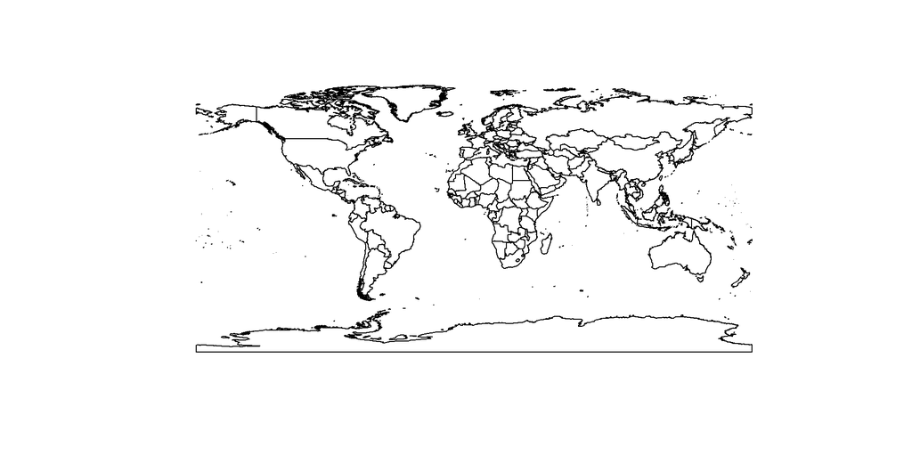

## This is the bounding box

The bounding box is the smallest rectangle enclosing all geometries — a key concept we’ll use later for cropping raster data.

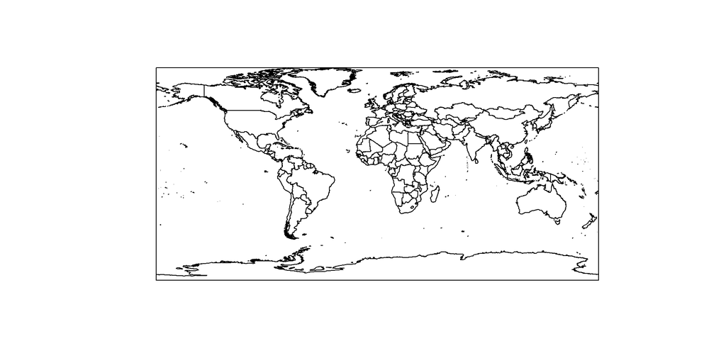

## Inspect your data: classics

There are no huge differences between the file we just imported and a regular data table.

```r
hello_world
```

```
Simple feature collection with 251 features and 5 fields
Geometry type: MULTIPOLYGON
Dimension:     XY
Bounding box:  xmin: -180 ymin: -89 xmax: 180 ymax: 83.6236
Geodetic CRS:  WGS 84
# A tibble: 251 × 6
     FID COUNTRY             ISO   COUNTRYAFF  AFF_ISO                  geometry
   <int> <chr>               <chr> <chr>       <chr>          <MULTIPOLYGON [°]>
 1     1 Afghanistan         AF    "Afghanist… "AF"    (((61.27655 35.60725, 61…
 2     2 Albania             AL    "Albania"   "AL"    (((19.57083 41.68527, 19…
 3     3 Algeria             DZ    "Algeria"   "DZ"    (((4.603354 36.88791, 4.…
 4     4 American Samoa      AS    "United St… "US"    (((-170.7439 -14.37555, …
 5     5 Andorra             AD    "Andorra"   "AD"    (((1.445836 42.60194, 1.…
 6     6 Angola              AO    "Angola"    "AO"    (((23.47611 -17.62584, 2…
 7     7 Anguilla            AI    "United Ki… "GB"    (((-63.16778 18.16445, -…
 8     8 Antarctica          AQ    " "         " "     (((-180 -84.30535, -179.…
 9     9 Antigua and Barbuda AG    "Antigua a… "AG"    (((-61.73806 16.98972, -…
10    10 Argentina           AR    "Argentina" "AR"    (((-71.85916 -41.01128, …
# ℹ 241 more rows
```

## Inspect your data: geometry type

Besides our general data inspection, we may also want to check the spatial features of our import. This check includes the geometric type (points? lines? polygons?) and the coordinate reference system.

```r
# type of geometry
sf::st_geometry(hello_world)
```

[output not shown]

## Inspect your data: multipolygons

Each polygon is defined by several connected points forming an enclosed area. A `MULTIPOLYGON` in `sf` means that a **single feature** (= one row) can consist of multiple separate polygons — for example, a country like Indonesia is one feature but made up of thousands of island polygons.

```r
attr(hello_world, "sf_column") |> # get geometry column name
  dplyr::pull(hello_world, var = _) |> # extract it
  dplyr::glimpse() # compact overview
```

```
sfc_MULTIPOLYGON of length 251; first list element: List of 1
 $ :List of 1
  ..$ : num [1:708, 1:2] 61.3 61.3 61.4 61.4 61.4 ...
 - attr(*, "class")= chr [1:3] "XY" "MULTIPOLYGON" "sfg"
```

## Inspect your data: CRS

Remember: The Coordinate Reference System is critical. A crucial step is to check the CRS of your geospatial data.

```r
# coordinate reference system
sf::st_crs(hello_world)
```

```
Coordinate Reference System:
  User input: WGS 84
  wkt:
GEOGCRS["WGS 84",
    DATUM["World Geodetic System 1984",
        ELLIPSOID["WGS 84",6378137,298.257223563,
            LENGTHUNIT["metre",1]]],
    PRIMEM["Greenwich",0,
        ANGLEUNIT["degree",0.0174532925199433]],
    CS[ellipsoidal,2],
        AXIS["geodetic latitude (Lat)",north,
            ORDER[1],
            ANGLEUNIT["degree",0.0174532925199433]],
        AXIS["geodetic longitude (Lon)",east,
            ORDER[2],
            ANGLEUNIT["degree",0.0174532925199433]],
    ID["EPSG",4326]]
```

## Spatial joins

Often, we want to combine geospatial datasets from different sources. The choice of an appropriate method depends, once again, on the data format. In the world of vector data, we usually speak of “spatial joins” when linking two vector datasets. Let’s pull in more spatially narrowed data.

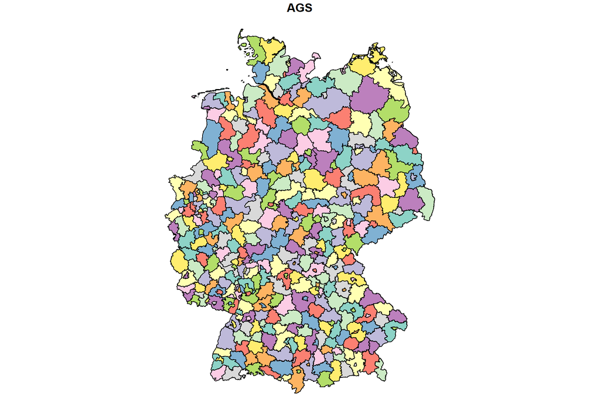

```r
german_districts <-
  sf::st_read(
    "./data/boundaries/VG250_KRS.shp",
    as_tibble = TRUE, # returns tibble, not plain df,
    quiet = TRUE
  )

plot(german_districts["AGS"]) # plot by district code
```

## Spatial joins

Using the synthetic survey geocoordinates, we can craft a toy example to demonstrate spatial joins. This is how they look.

```r
points <-
  readRDS(
    "./data/survey/synthetic_survey_geocoordinates.rds"
  ) |>
  sf::st_transform(sf::st_crs(german_districts)) # match CRS

points
```

```
Simple feature collection with 500 features and 5 fields
Geometry type: POINT
Dimension:     XY
Bounding box:  xmin: 294988.7 ymin: 5267839 xmax: 890892.3 ymax: 6080921
Projected CRS: ETRS89 / UTM zone 32N
# A tibble: 500 × 6
     age female citizenship income      rent_avg           geometry
 * <dbl>  <int>       <int> <ord>          <dbl>        <POINT [m]>
 1    51      1           0 2500-3000 €     6.21 (540828.5 5857602)
 2    36      0           1 1000-1500 €     5.44 (367922.1 5708271)
 3    47      1           1 1500-2000 €     5.35 (380782.8 5718445)
 4    51      0           0 2000-2500 €     9.46 (564543.3 5948916)
 5    46      0           1 > 5000 €        6.81 (829425.9 5819662)
 6    45      1           1 4000-4500 €     5.70 (472899.1 5781689)
 7    53      1           1 2500-3000 €     6.36 (377382.8 5601424)
 8    38      0           1 3500-4000 €     4.22   (451344 5822381)
 9    33      1           1 <NA>            4.87 (868183.5 5696081)
10    43      1           1 3500-4000 €     7.39 (555127.2 5391885)
# ℹ 490 more rows
```

```r
plot(sf::st_geometry(points)) # point locations
```

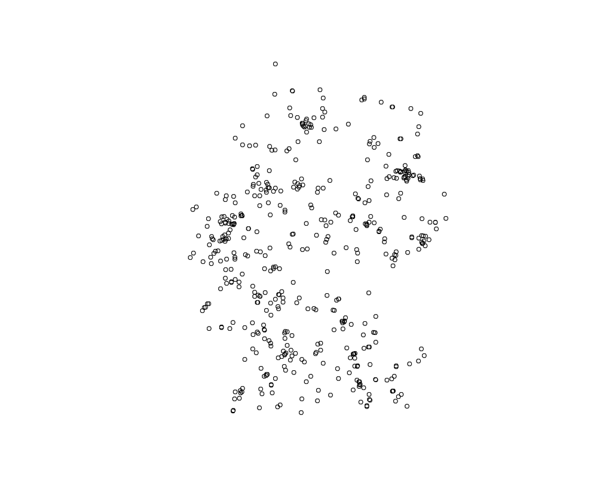

## Spatial joins

It would be nice if we had regional identifiers in our points data, but there aren’t any. This issue shows where spatial joins come in handy. We can use `sf::st_join()` to extract this information.

```r
points_ags <- sf::st_join(points, german_districts["AGS"]) # join by location

points_ags
```

```
Simple feature collection with 500 features and 6 fields
Geometry type: POINT
Dimension:     XY
Bounding box:  xmin: 294988.7 ymin: 5267839 xmax: 890892.3 ymax: 6080921
Projected CRS: ETRS89 / UTM zone 32N
# A tibble: 500 × 7
     age female citizenship income      rent_avg           geometry AGS
 * <dbl>  <int>       <int> <ord>          <dbl>        <POINT [m]> <chr>
 1    51      1           0 2500-3000 €     6.21 (540828.5 5857602) 03358
 2    36      0           1 1000-1500 €     5.44 (367922.1 5708271) 05513
 3    47      1           1 1500-2000 €     5.35 (380782.8 5718445) 05562
 4    51      0           0 2000-2500 €     9.46 (564543.3 5948916) 01060
 5    46      0           1 > 5000 €        6.81 (829425.9 5819662) 12067
 6    45      1           1 4000-4500 €     5.70 (472899.1 5781689) 05758
 7    53      1           1 2500-3000 €     6.36 (377382.8 5601424) 07131
 8    38      0           1 3500-4000 €     4.22   (451344 5822381) 03460
 9    33      1           1 <NA>            4.87 (868183.5 5696081) 14625
10    43      1           1 3500-4000 €     7.39 (555127.2 5391885) 08117
# ℹ 490 more rows
```

## There’s more

In this course, we only use a subset of the options for spatial joins in `sf`. Please refer to the official [sf cheat sheet](https://rstudio.github.io/cheatsheets/sf.pdf).

[figure not shown]

## Finally: Transforming the CRS

We have to change our CRS fairly often depending on our data sources. That’s easily doable in `sf` using the `sf::st_transform()`. Here’s a closer look.

```r
sf::st_crs(german_districts)$epsg # current CRS
```

```
[1] 25832
```

Let’s pretend we want to use the EPSG code `4326` — no problem!

```r
german_districts_4326 <- sf::st_transform(german_districts, 4326) # reproject

sf::st_crs(german_districts_4326)$epsg # verify new CRS
```

```
[1] 4326
```

## Exercise 2_1: Vector Data Refresher

[🖱 Click here to open the exercise](https://denabel.github.io/advanced_geospatial_26/exercises/2_1_Vector_Data_Refresher.html)

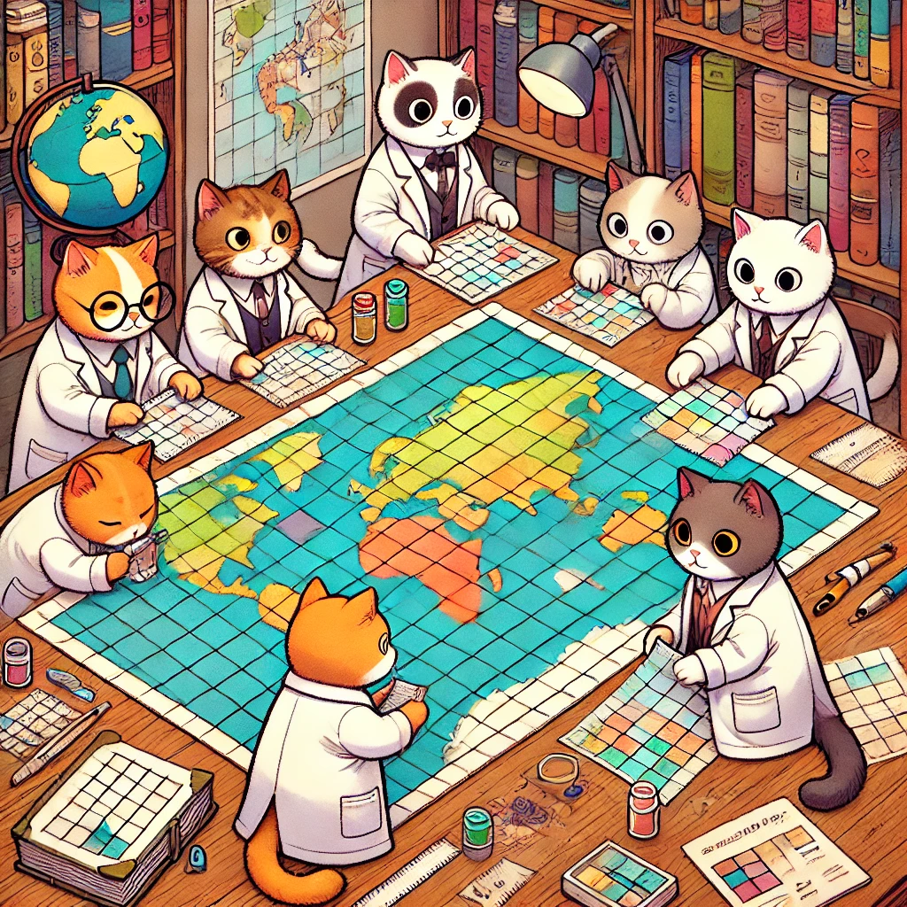

*AI-assisted picture*

## Raster data

Now that we’ve refreshed vector data, let’s look at the other major spatial data format. While vector data represent discrete features (points, lines, polygons), raster data represent continuous surfaces as a grid of cells.

## Difference to vector data

- Other data format(s), different file extensions
- Geometries do not differ within one dataset
- Other geospatial operations possible
- Can be way more efficient and straightforward to process
- It’s like working with simple tabular data

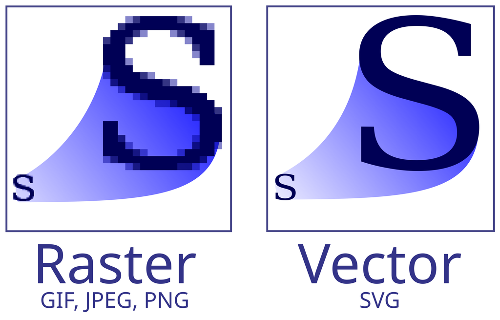

Source: [Von Yug, modifications by Cfaerber et al., CC BY-SA 2.5](https://commons.wikimedia.org/w/index.php?curid=1183592)

## Visual difference between vector and raster data

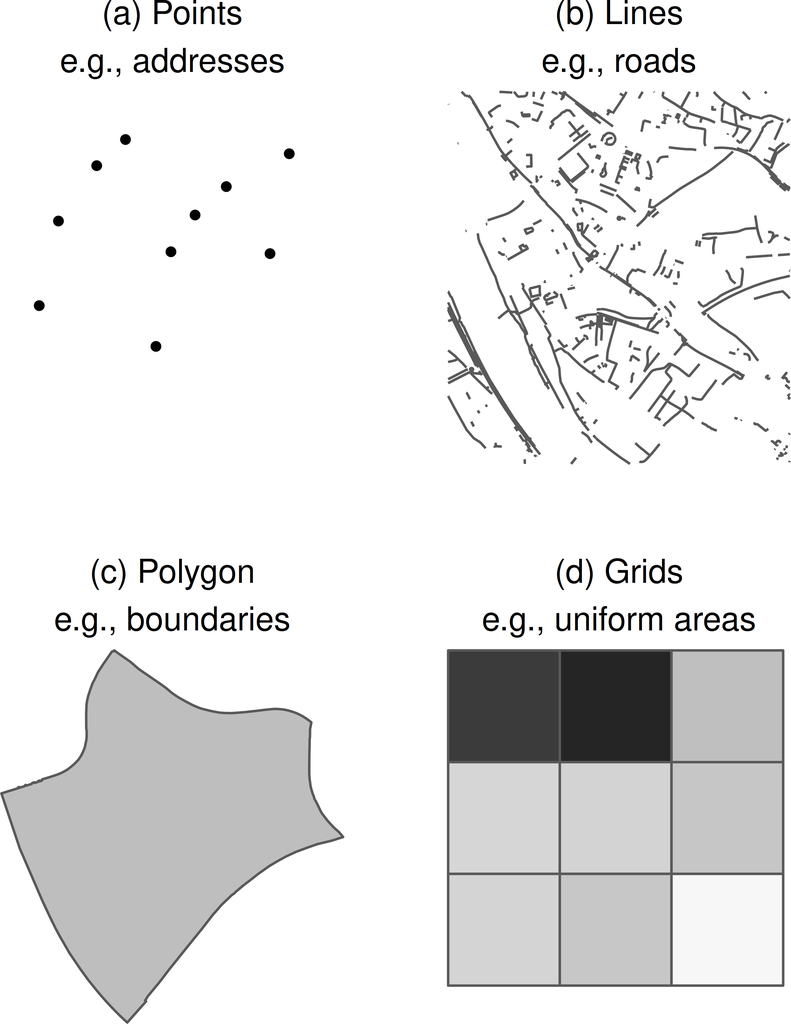

## What exactly are raster data?

- Hold information on (most of the time) evenly shaped grid cells
- Basically, a simple data table
- Each cell represents one observation

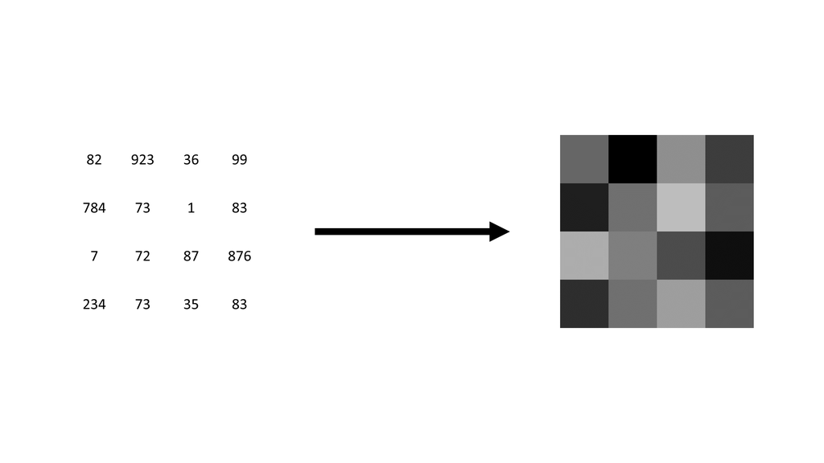

## Metadata

- Information about geometries is globally stored
- They are the same for all observations
- Their location in space is defined by their cell location in the data table
- Without this information, raster data would be simple image files

[figure not shown]

Source: [Know Your Meme](https://knowyourmeme.com/memes/theyre-the-same-picture)

## Important metadata

**Raster Dimensions** $\rightarrow$ number of columns, rows, and cells

**Extent** $\rightarrow$ similar to bounding box in vector data

**Resolution** $\rightarrow$ the size of each raster cell

**Coordinate reference system** $\rightarrow$ defines where on the earth’s surface the raster layer lies

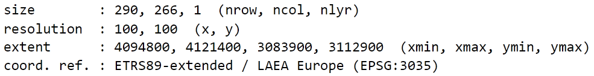

## Setting up a raster dataset is easy

```r
input_data <- matrix(sample(1:100, 16), nrow = 4) # 4x4 random values

raster_layer <- terra::rast(input_data) # matrix → raster

raster_layer
```

```
class       : SpatRaster
size        : 4, 4, 1  (nrow, ncol, nlyr)
resolution  : 1, 1  (x, y)
extent      : 0, 4, 0, 4  (xmin, xmax, ymin, ymax)
coord. ref. :
source(s)   : memory
name        : lyr.1
min value   :     2
max value   :    95
```

## We can already plot it

This toy example shows: a raster is just a matrix with spatial metadata. The real power comes when we load actual geodata.

```r
terra::plot(raster_layer)
```

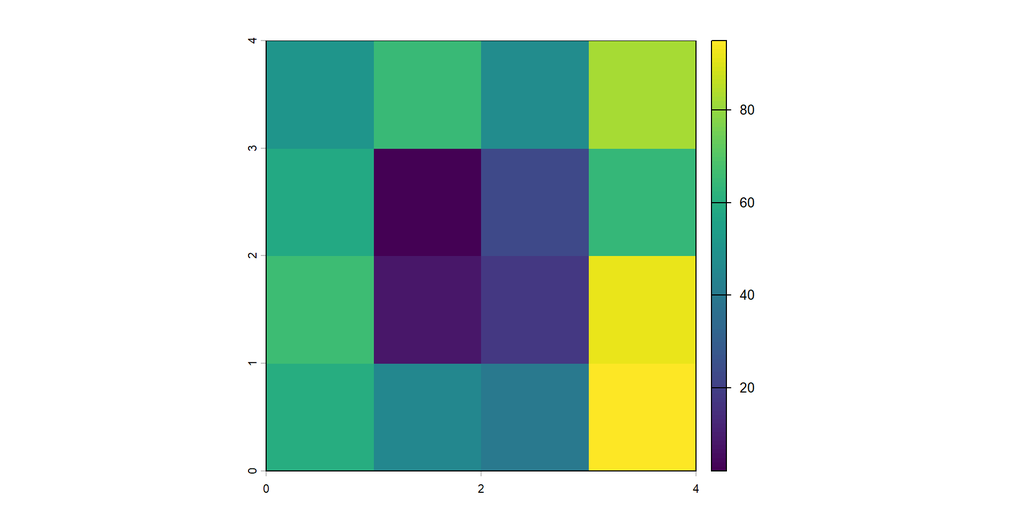

## File formats/extensions

- GeoTIFF `.tif`
- Gridded data `.grd`
- Network common data format `.nc`
- Esri grid `.asc`
- …
- Sometimes, raster data come even in a text format, such as `CSV`

## Implementations in `R`

`terra` is the most commonly used package for raster data in `R`.

Some other developments, e.g., in the `stars` package, also implement an interface to simple features in `sf`. We will work with `stars` later in this course.

The `terra` package helps to employ zonal statistics. But the `spatstat` package is even more elaborate.

## Loading raster tiffs (German Census Data 2022)

The `./data/z22/` folder contains 1 km² grid data from the German Census 2022, gathered via the [`z22` R package](https://github.com/JsLth/z22) (available on [CRAN](https://cran.r-project.org/package=z22)). Single variables are stored as `.tif`, categorical variables with multiple groups as `.nc`.

**Looking up Census variable names**

File names correspond to Census features (e.g., `population.tif`, `rent_avg.tif`). For descriptions, you have two options:

1. **In R** (if `z22` is installed): `z22::z22_features()` lists all available features; `z22::z22_categories("age_short")` decodes the layers inside `.nc` files.
2. **Online**: Browse the [Census 2022 database](https://ergebnisse.zensus2022.de/datenbank/online/themes) for full variable documentation.

## Loading raster tiffs (German Census Data 2022)

Loading raster data in `terra` is straightforward. For this purpose, we use the function `terra::rast()`.

```r
pop_grid_ger_2022 <- terra::rast("./data/z22/population.tif") # load raster

pop_grid_ger_2022 # inspect metadata
```

```
class       : SpatRaster
size        : 859, 641, 1  (nrow, ncol, nlyr)
resolution  : 1000, 1000  (x, y)
extent      : 4031000, 4672000, 2689000, 3548000  (xmin, xmax, ymin, ymax)
coord. ref. : ETRS89-extended / LAEA Europe (EPSG:3035)
source      : population.tif
name        : cat_0
min value   :     3
max value   : 24164
```

## Loading raster tiffs (German Census Data 2022)

Let’s load another dataset to compare structures because that’s really easy in `terra`.

```r
age_under_18_grid_2022 <- terra::rast("./data/z22/age_under_18.tif") # % under 18

age_under_18_grid_2022 # compare metadata with population
```

```
class       : SpatRaster
size        : 859, 641, 1  (nrow, ncol, nlyr)
resolution  : 1000, 1000  (x, y)
extent      : 4031000, 4672000, 2689000, 3548000  (xmin, xmax, ymin, ymax)
coord. ref. : ETRS89-extended / LAEA Europe (EPSG:3035)
source      : age_under_18.tif
name        :  cat_0
min value   :   0.15
max value   : 100.00
```

## Compare layers by plotting

```r
terra::plot(
  pop_grid_ger_2022
)
```

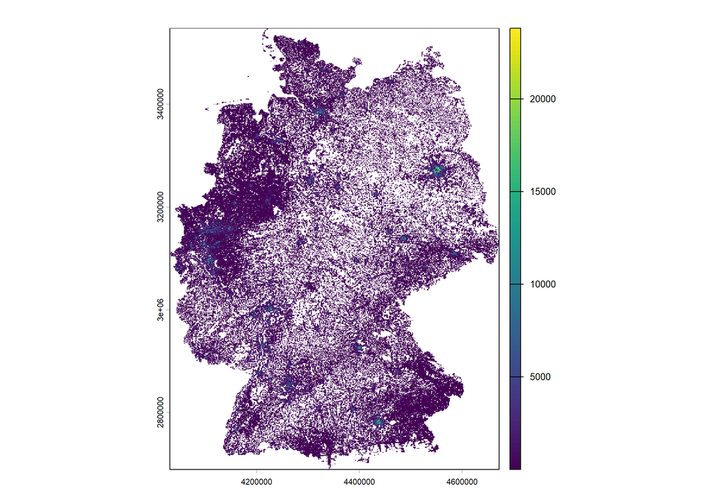

```r
terra::plot(
  age_under_18_grid_2022
)
```

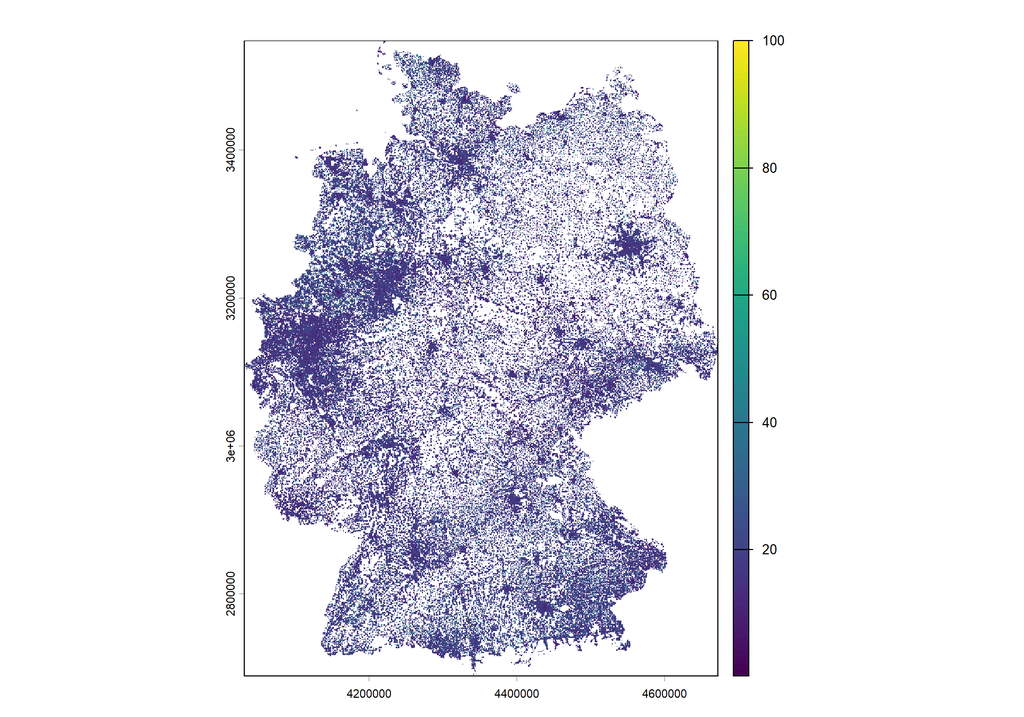

## Working with raster values

Working with raster data is straightforward — quite speedy, yet not as comfortable as working with `sf` objects.

`terra::global()` computes summary statistics efficiently (without loading all values into memory):

```r
terra::global(pop_grid_ger_2022, fun = "mean", na.rm = TRUE) # efficient summary
```

```
          mean
cat_0 392.8003
```

For custom statistics, extract the raw values as a vector with `terra::values()`:

```r
all_raster_values <- terra::values(pop_grid_ger_2022) # all cells as vector
mean(all_raster_values, na.rm = TRUE) # same result, more flexible
```

```
[1] 392.8003
```

For large rasters, prefer `terra::global()` — it’s faster and memory-friendly.

## Combining raster layers to calculate new values

Although raster data are simple data tables, working with them is a bit different compared to, e.g., simple features. We can combine raster layers using basic math. Here, we multiply population counts by the share of under-18s to get the absolute number of young people per cell.

```r
young_people <-
  pop_grid_ger_2022 * # population count
  (age_under_18_grid_2022 / 100) # × share under 18

young_people
```

```
class       : SpatRaster
size        : 859, 641, 1  (nrow, ncol, nlyr)
resolution  : 1000, 1000  (x, y)
extent      : 4031000, 4672000, 2689000, 3548000  (xmin, xmax, ymin, ymax)
coord. ref. : ETRS89-extended / LAEA Europe (EPSG:3035)
source(s)   : memory
varname     : population
name        :    cat_0
min value   :    1.125
max value   : 4180.761
```

[figure not shown]

## Loading raster data with `stars`

Later, we will work with multidimensional raster data cubes. While it is possible to work with them in `terra`, `stars` is way more elaborate (we’ll discuss it tomorrow in more detail). So, here is an example of how to load raster data into `stars`.

```r
pop_grid_ger_2022_stars <-
  stars::read_stars("./data/z22/population.tif") # same data, different package

pop_grid_ger_2022_stars # note the different output format
```

```
stars object with 2 dimensions and 1 attribute
attribute(s):
                Min. 1st Qu. Median     Mean 3rd Qu.  Max.    NAs
population.tif     3      17     64 392.8003     281 24164 340063
dimension(s):
  from  to  offset delta                       refsys point x/y
x    1 641 4031000  1000 ETRS89-extended / LAEA Eu... FALSE [x]
y    1 859 3548000 -1000 ETRS89-extended / LAEA Eu... FALSE [y]
```

## `stars` objects can also be plotted

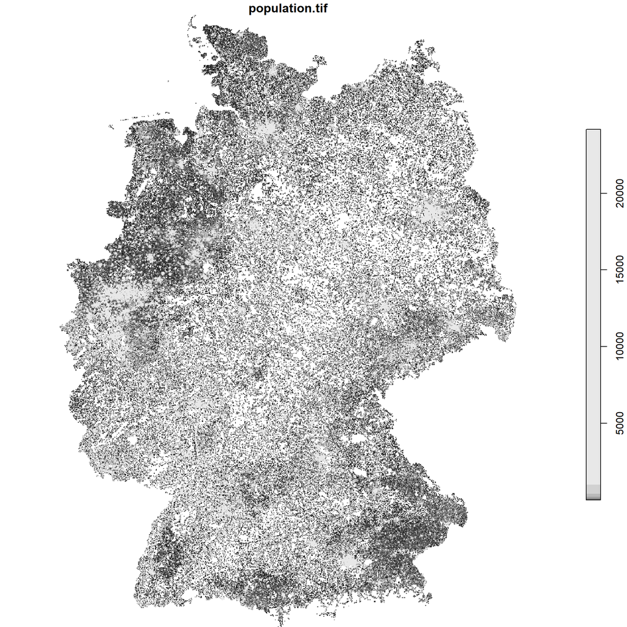

```r
plot(pop_grid_ger_2022_stars)
```

## Finally: Transforming the CRS

As mentioned before, we may also have to change the CRS of our raster data. Returning to `terra`, this is not called ‘transforming’ but ‘projecting’ (which makes sense, right?).

```r
terra::crs(pop_grid_ger_2022, describe = TRUE)$code # current CRS
```

```
[1] "3035"
```

Let’s pretend we want to use the EPSG code `4236` — no problem!

```r
pop_grid_ger_2022_3035 <- terra::project(pop_grid_ger_2022, "EPSG:4236") # reproject

terra::crs(pop_grid_ger_2022_3035, describe = TRUE)$code # verify new CRS
```

```
[1] "4236"
```

## Exercise 2_2: Basic Raster Operations

[🖱 Click here to open the exercise](https://denabel.github.io/advanced_geospatial_26/exercises/2_2_Basic_Raster_Operations.html)

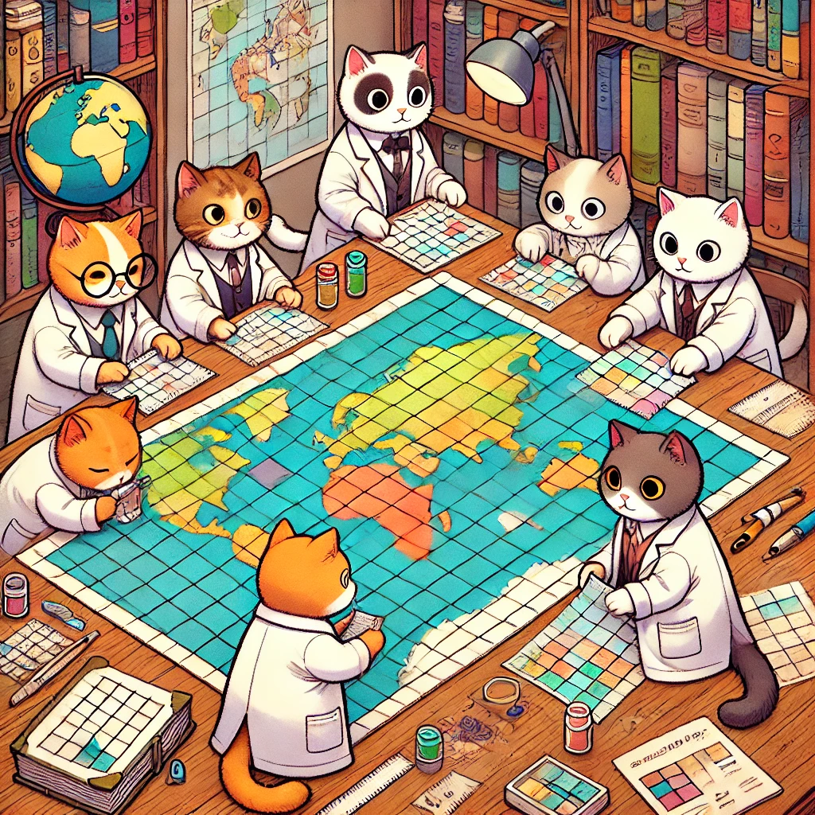

*AI-assisted picture*